# Seasonal Variations in Young Adult Shootings in NYC

N. Nicol

2023-09-26

This report was produced from a list of every shooting incident that occurred in NYC going back to 2006 through the end of the previous calendar year, April 27th 2023 in this case. This data is manually extracted every quarter and reviewed by the Office of Management Analysis and Planning before being posted on the NYPD website. Each record represents a shooting incident in NYC and includes information about the event, the location and time of occurrence. In addition, information related to suspect and victim demographics is also included.

The NYPD Historic shooting incident dataset from which this graphic was sourced can be found here: https://catalog.data.gov/dataset/nypd-shooting-incident-data-historic/resource/c564b578-fd8a-4005-8365-34150d306cc4 *note: code for data manipulation can be found in the appendix

## Young Adult Shootings

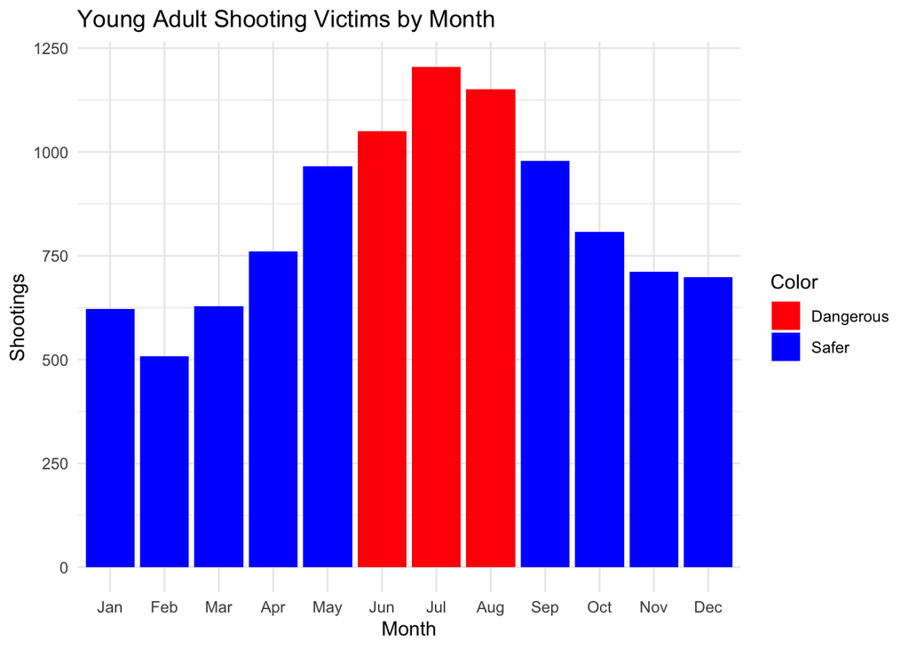

Young Adults Victims were classified as 18-24 years old and peaked in the summer months of June through August.

## Middle Aged Adult Shootings

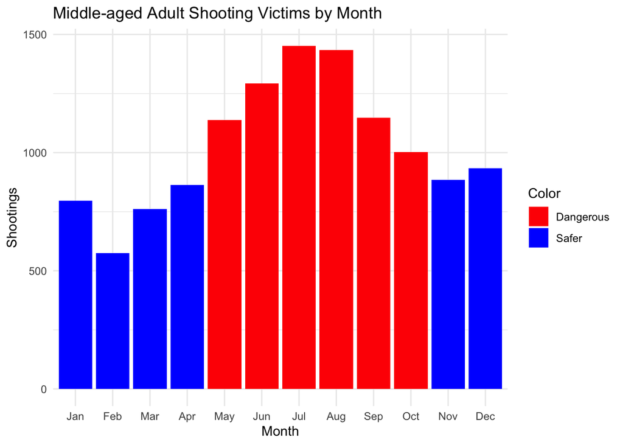

Middle-Aged Victims were classified as 25-44 years old and peaked in the summer months of June through August. As seen in the figure, they were the most frequent and had 6 months surpassing 1000 victims since 2006.

## Older Adult Shootings

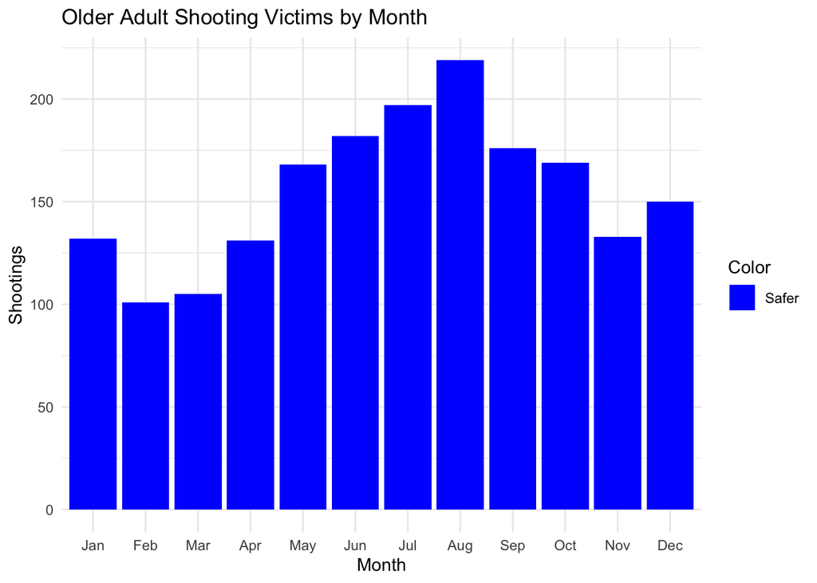

Older Adults Victims were classified as 45-64 years old and peaked in the summer months of June through August as well. Victims shot much less frequently in this age range compared to the other groups.

## Summary

As you can see, adult shootings rates in NYC vary by victim age and season with shootings typically peaking in July. Interestingly, peak shooting seasons tend to shift later in the summer as victims grow older. While perpetrator data was unfortunately too sparse to effectively evaluate, if we accept that personal disputes are most likely to occur between individuals of a similar age, then we can assume that perps and victims are generally in a similar age bracket. From this, we can speculate that the seasonal delayed surge in shootings among older adults might be attributed to lower impulsiveness or a greater aptitude for planning, if not at least greater patience for alternative conflict resolution.

### Bias Mitigation

As with all analysis, bias must be considered throughout the data collection and reporting process. I was interested in seasonal effects on shootings because I love summer and live in the Midwest USA, an inland location that suffers wild temperature swings each year. On the same lakes I can drive my car on in the winter, I can stew in algae infested 78F water in the summer. While I point out the correlation between season and shooting frequency, there are obviously many factors at play. Warmer NYC months may not mean that someone is more likely to get shot, but instead may simply be a side effect of more people out and about for more hours of the day. I make assumptions about age affecting rational thinking and impulsiveness. This reflects my personal bias of impulsiveness being associated with young people and is backed up by studies that show frontal lobe development doesn’t end until an average age of 25 years old.

Another source of bias in the way I reported the data is the age brackets used. While the middle-aged shootings graph implies that a person in that age bracket is most likely to be a victim, it doesn’t normalize for the number of years included in the age range. Stated in other words, the young adult age bracket only spans 6 years: 18 - 24. The middle age and older age brackets however each span approximately 20 years. All else equal, there would logically be more victims in these larger age brackets simply due to the fact that they span a greater range and therefore have more people in them. This further highlights the drastically increased young adult victim numbers compared to older adults. If the young adults and middle aged adult charts had been normalized to the same number of years (multiply middle adult by 6/20?) then I hypothesize that the young adult category would actually claim victims at the highest frequency.

# Appendix

```
# Load the required libraries
library(dplyr)
library(tidyverse)
library(ggplot2)
library(lubridate)


# Read the data
shootings <- read.csv("https://data.cityofnewyork.us/api/views/833y-fsy8/rows.csv")

# Select relevant columns and filter data for young adult victims
Young_adult_shot <- shootings %>%
  select(OCCUR_DATE, VIC_AGE_GROUP) %>%
  filter(VIC_AGE_GROUP == '18-24')

# Convert OCCUR_DATE to Date format
Young_adult_shot$OCCUR_DATE <- as.Date(Young_adult_shot$OCCUR_DATE, format = "%m/%d/%Y")

# Create a frequency table for each month
frequency_table <- table(month(Young_adult_shot$OCCUR_DATE))

# Convert frequency table to data frame
frequency_df <- as.data.frame(frequency_table)
names(frequency_df) <- c("Month", "Frequency")

# Create a column indicating whether Frequency > 850
frequency_df$Color <- ifelse(frequency_df$Frequency > 1000, "Dangerous", "Safer")

{r old_graph, include=FALSE}
# Select relevant columns and filter data for young adult victims
old_adult_shot <- shootings %>%
  select(OCCUR_DATE, VIC_AGE_GROUP) %>%
  filter(VIC_AGE_GROUP == '45-64')

# Convert OCCUR_DATE to Date format
old_adult_shot$OCCUR_DATE <- as.Date(old_adult_shot$OCCUR_DATE, format = "%m/%d/%Y")

# Create a frequency table for each month
frequency_table3 <- table(month(old_adult_shot$OCCUR_DATE))

```

[output cut: 40 more lines]

```
  geom_bar(stat = "identity") +
  scale_fill_manual(values = c("red", "blue")) +  # Set colors
  labs(title = "Middle-aged Adult Shooting Victims by Month",
       x = "Month",
       y = "Shootings") +
  theme_minimal()


ggplot(frequency_df3, aes(x = factor(Month, labels = month.abb), y = Frequency, fill = Color)) +
  geom_bar(stat = "identity") +
  scale_fill_manual(values = c("blue")) +  # Set colors
  labs(title = "Older Adult Shooting Victims by Month",
       x = "Month",
       y = "Shootings") +
  theme_minimal()
```